# Canine Epilepsy - Sequence Processing

BJC

3/10/2020

## Data

This data is from MiSeq V4 16S rRNA gene sequencing of fecal samples from 28 dogs. Primers are included at the start of the reads. The sequenced amplicon is ~290nts long, with very little length variation.

## Setup

Load libraries, setup paths, prepare environment:

```r
library(dada2);packageVersion("dada2")
```

```
## [1] '1.15.2'
```

```r
path.fastq <- "~/Desktop/Epilepsy/demux" # CHANGE ME to location of the raw fastq data
path.filt <- file.path(path.fastq, "filtered")
path.fig <- "Figures/" # Local path. Assumes working directory is this files location
path.rds <- "RDS/" # Local path...
fnF <- list.files(path.fastq, pattern="_F.fastq.gz", full.names=TRUE)
fnR <- list.files(path.fastq, pattern="_R.fastq.gz", full.names=TRUE)
fnMeta <- "epilepsy_mapping.txt" # Local path...
# Primer seqeuences are included on the reads
F515 <- "GTGCCAGCAGCCGCGGT" # 17 nt
R806 <- "GGACTACHVGGGTWTCTAAT" # 20nt
```

Inspect quality profile:

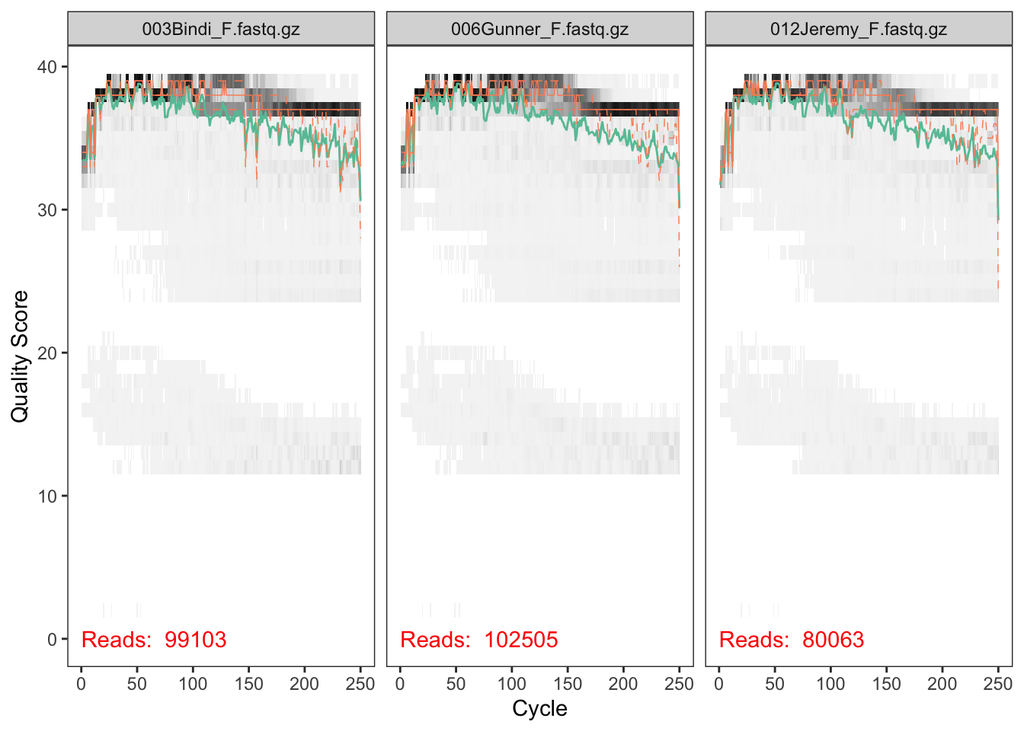

```r
plotQualityProfile(fnF[c(3,6,12)])
```

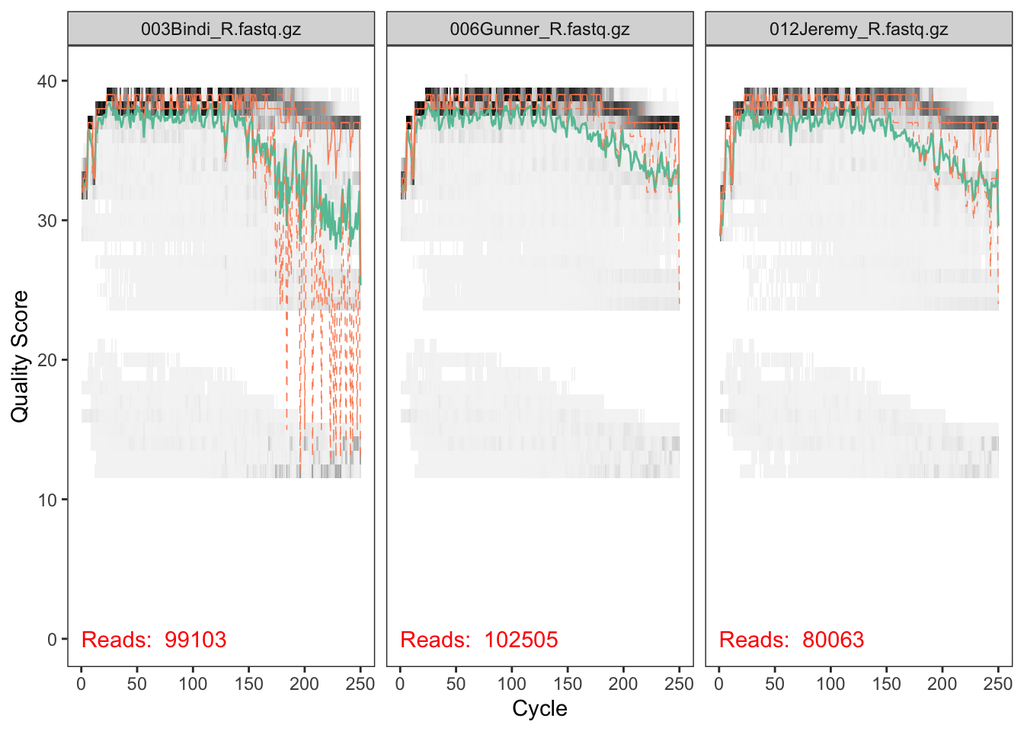

```r
plotQualityProfile(fnR[c(3,6,12)])
```

Quality is good, but some noticeable degradation starting at base-pair ~180 in the reverse reads. Choose `truncLen=c(240,180)` as the truncation parameters, which is more than enough to substantially overlap given the ~290nt sequenced amplicon length.

Perform filtering:

```r
filtF <- file.path(path.filt, basename(fnF))
filtR <- file.path(path.filt, basename(fnR))
out <- filterAndTrim(fnF, filtF, fnR, filtR,
                     trimLeft=c(17,20), truncLen=c(240, 180), maxEE=2,
                     multithread=TRUE)
out
```

```
##                        reads.in reads.out
## 001Lumos_F.fastq.gz       97962     89910
## 002Sunny_F.fastq.gz      105508     96931
## 003Bindi_F.fastq.gz       99103     90845
## 004Bee_F.fastq.gz         84477     78203
## 005Ticket_F.fastq.gz     125421    116490
## 006Gunner_F.fastq.gz     102505     93905
## 007Ziva_F.fastq.gz        66022     61668
## 008Tony_F.fastq.gz        88273     82144
## 009Callie_F.fastq.gz      93694     86027
## 010Sparkle_F.fastq.gz     56600     52704
## 011Marti_F.fastq.gz       80365     73918
## 012Jeremy_F.fastq.gz      80063     73430
## 013Savannah_F.fastq.gz    77937     72907
## 014Jai_F.fastq.gz         94719     88522
## 015Eames_F.fastq.gz       28806     27459
## 016Fernando_F.fastq.gz    36769     34830
## 017Halo_F.fastq.gz        46690     44071
## 018Oakley_F.fastq.gz      19287     18509
## 019Jojo_F.fastq.gz        29476     27723
## 020Petey_F.fastq.gz         127        68
## 021Frodo_F.fastq.gz       75628     71309
## 022Archie_F.fastq.gz      41446     39514
## 023Trophy_F.fastq.gz      72482     66965
## 024Alibi_F.fastq.gz       79128     72201
## 025Bella_F.fastq.gz       76654     70538
## 026Andy_F.fastq.gz        46629     42680
## 027Fritz_F.fastq.gz     1269575   1183064
## 028Sophie_F.fastq.gz      74261     68863
```

```r
summary(out[,2]/out[,1])
```

```
##    Min. 1st Qu.  Median    Mean 3rd Qu.    Max.
##  0.5354  0.9181  0.9281  0.9161  0.9367  0.9597
```

Kept a high fraction of reads. One library appears to have failed, but other than that all look godo with solid read counts.

Learn errors:

```r
errF <- learnErrors(filtF, multithread=TRUE)
```

```
## 105340517 total bases in 472379 reads from 5 samples will be used for learning the error rates.
```

```r
errR <- learnErrors(filtR, multithread=TRUE)
```

```
## 100472320 total bases in 627952 reads from 7 samples will be used for learning the error rates.
```

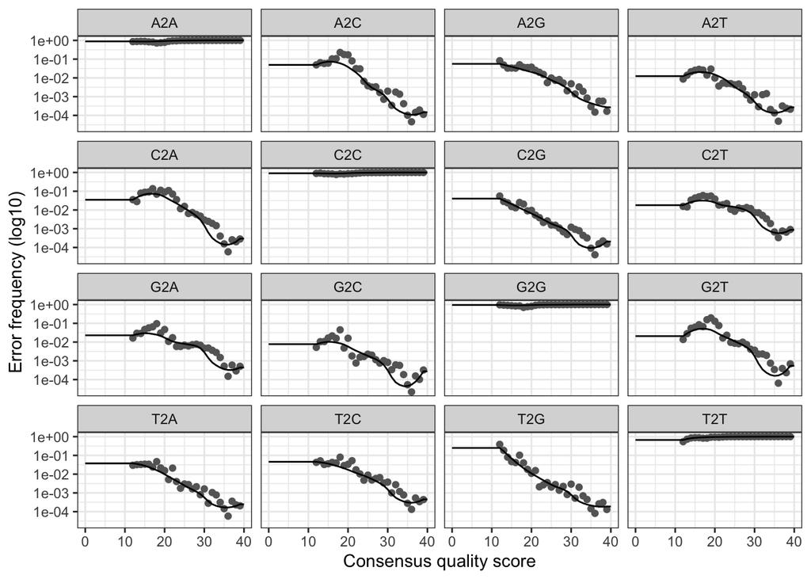

```r
plotErrors(errF)
```

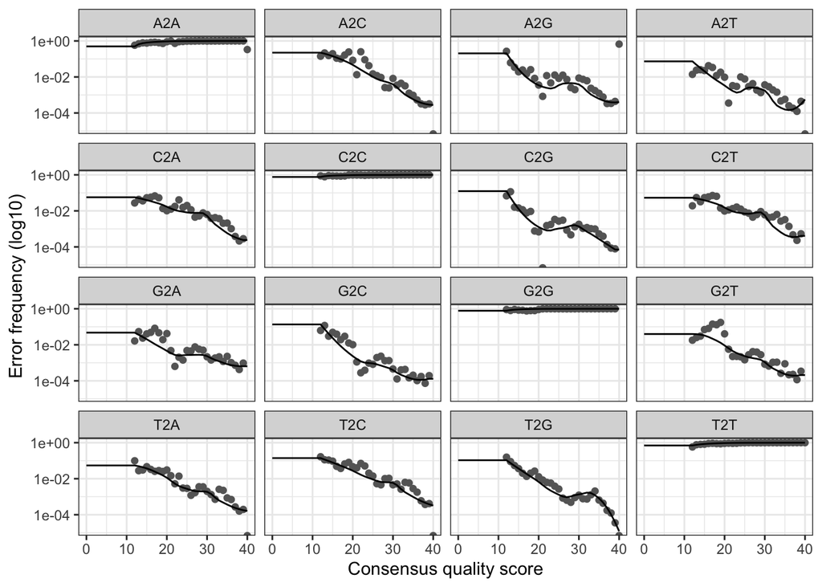

```r
plotErrors(errR)
```

Error models look solid. Going to do sample inference using `pool=TRUE` to maximize the ability to detect rare *Lactobacillus* variants in each sample (takes ~15 minutes on my 2017 MacBook Pro):

```r
ddF <- dada(filtF, err=errF, pool=TRUE, multithread=TRUE)
```

```
## 28 samples were pooled: 2925398 reads in 197562 unique sequences.
```

```r
ddR <- dada(filtR, err=errR, pool=TRUE, multithread=TRUE)
```

```
## 28 samples were pooled: 2925398 reads in 149851 unique sequences.
```

Merge denoised forward and reverse reads:

```r
mm <- mergePairs(ddF, filtF, ddR, filtR, verbose=TRUE)
```

```
## 88807 paired-reads (in 590 unique pairings) successfully merged out of 89627 (in 981 pairings) input.
```

```
## 95744 paired-reads (in 602 unique pairings) successfully merged out of 96646 (in 976 pairings) input.
```

```
## 89289 paired-reads (in 516 unique pairings) successfully merged out of 90413 (in 1046 pairings) input.
```

```
## 75595 paired-reads (in 807 unique pairings) successfully merged out of 77934 (in 1295 pairings) input.
```

```
## 114611 paired-reads (in 1011 unique pairings) successfully merged out of 116057 (in 1587 pairings) input.
```

```
## 91582 paired-reads (in 1261 unique pairings) successfully merged out of 93181 (in 2054 pairings) input.
```

```
## 59996 paired-reads (in 618 unique pairings) successfully merged out of 61266 (in 1095 pairings) input.
```

```
## 79755 paired-reads (in 674 unique pairings) successfully merged out of 81725 (in 1270 pairings) input.
```

```
## 84062 paired-reads (in 981 unique pairings) successfully merged out of 85623 (in 1529 pairings) input.
```

```
## 51337 paired-reads (in 960 unique pairings) successfully merged out of 52377 (in 1375 pairings) input.
```

```
## 71608 paired-reads (in 907 unique pairings) successfully merged out of 73464 (in 1394 pairings) input.
```

```
## 71406 paired-reads (in 609 unique pairings) successfully merged out of 72974 (in 1010 pairings) input.
```

```
## 70668 paired-reads (in 750 unique pairings) successfully merged out of 72322 (in 1434 pairings) input.
```

```
## 85919 paired-reads (in 897 unique pairings) successfully merged out of 87799 (in 1800 pairings) input.
```

```
## 26545 paired-reads (in 215 unique pairings) successfully merged out of 27142 (in 396 pairings) input.
```

```
## 33925 paired-reads (in 479 unique pairings) successfully merged out of 34582 (in 785 pairings) input.
```

```
## 43047 paired-reads (in 453 unique pairings) successfully merged out of 43826 (in 750 pairings) input.
```

```
## 17994 paired-reads (in 213 unique pairings) successfully merged out of 18362 (in 348 pairings) input.
```

```
## 27286 paired-reads (in 453 unique pairings) successfully merged out of 27607 (in 615 pairings) input.
```

```
## 42 paired-reads (in 30 unique pairings) successfully merged out of 58 (in 46 pairings) input.
```

```
## 69972 paired-reads (in 843 unique pairings) successfully merged out of 70994 (in 1214 pairings) input.
```

```
## 38641 paired-reads (in 343 unique pairings) successfully merged out of 39307 (in 655 pairings) input.
```

```
## 65104 paired-reads (in 1200 unique pairings) successfully merged out of 66448 (in 1811 pairings) input.
```

```
## 69983 paired-reads (in 861 unique pairings) successfully merged out of 71898 (in 1406 pairings) input.
```

```
## 69459 paired-reads (in 612 unique pairings) successfully merged out of 70298 (in 997 pairings) input.
```

```
## 41827 paired-reads (in 519 unique pairings) successfully merged out of 42554 (in 775 pairings) input.
```

```
## 1157305 paired-reads (in 2803 unique pairings) successfully merged out of 1175302 (in 7704 pairings) input.
```

```
## 67049 paired-reads (in 1244 unique pairings) successfully merged out of 68377 (in 1903 pairings) input.
```

Make sequence table and remove chimeras:

```r
sta <- makeSequenceTable(mm)
# Pooled chimera removal since denoising was also pooled
st <- removeBimeraDenovo(sta, method="pooled", minFoldParentOverAbundance=4, multithread=TRUE)
# st <- removeBimeraDenovo(sta, multithread=TRUE) #
sum(st)/sum(sta);dim(st)
```

```
## [1] 0.9387181
```

```
## [1]  28 655
```

Assign taxonomy:

```r
tax <- assignTaxonomy(st, "~/tax/silva_nr_v128_train_set.fa.gz", tryRC=TRUE, multithread=TRUE)
taxp <- addSpecies(tax, "~/tax/silva_species_assignment_v128.fa.gz", tryRC=TRUE)
```

Save the relevant objects as RDS files to be read in by the analysis workflow:

```r
saveRDS(st, file.path(path.rds, "st.rds"))
saveRDS(tax, file.path(path.rds, "tax.rds"))
saveRDS(taxp, file.path(path.rds, "taxp.rds"))
```

Check if lactos are there:

```r
is.lacto <- taxp[,6] %in% "Lactobacillus"
sum(is.lacto)
```

```
## [1] 8
```

```r
unname(taxp[is.lacto,6:7])
```

```
##      [,1]            [,2]
## [1,] "Lactobacillus" NA
## [2,] "Lactobacillus" NA
## [3,] "Lactobacillus" NA
## [4,] "Lactobacillus" "reuteri"
## [5,] "Lactobacillus" NA
## [6,] "Lactobacillus" NA
## [7,] "Lactobacillus" "aviarius"
## [8,] "Lactobacillus" NA
```